# Output Analysis

Term 6 40.319 Simulation Modelling Analysis Project

Ong Kai Xin Chloe, Muhammad Zulfiqar, Yong Zhe Rui Gabriel and Pang Yew Ju Ethan

2023-03-20

## Preparing Data and Libraries for analysis

### Loading Libraries

```r
library(tidyr)
library(dplyr)
```

```r
library(ggplot2)
library(factoextra)
```

### Read Train Data

```r
train1 <- read.csv("trainData1.csv")
train2 <- read.csv("trainData2.csv")
train3 <- read.csv("trainData3.csv")
train4 <- read.csv("trainData4.csv")
train5 <- read.csv("trainData5.csv")
train6 <- read.csv("trainData6.csv")
train7 <- read.csv("trainData7.csv")
train8 <- read.csv("trainData8.csv")
train9 <- read.csv("trainData9.csv")
train10 <- read.csv("trainData10.csv")
train11 <- read.csv("trainData11.csv")
train12 <- read.csv("trainData12.csv")
train13 <- read.csv("trainData13.csv")
train14 <- read.csv("trainData14.csv")
train15 <- read.csv("trainData15.csv")
train16 <- read.csv("trainData16.csv")
train17 <- read.csv("trainData17.csv")
train18 <- read.csv("trainData18.csv")
train19 <- read.csv("trainData19.csv")
train20 <- read.csv("trainData20.csv")
train <- rbind(train1,train2,train3,train4,
               train5,train6,train7,train8,
               train9,train10,train11,train12,
               train13,train14,train15,train16,
               train17,train18,train19,train20)
```

### Read station data

```r
station1 <- read.csv("stationData1.csv")
station2 <- read.csv("stationData2.csv")
station3 <- read.csv("stationData3.csv")
station4 <- read.csv("stationData4.csv")
station5 <- read.csv("stationData5.csv")
station6 <- read.csv("stationData6.csv")
station7 <- read.csv("stationData7.csv")
station8 <- read.csv("stationData8.csv")
station9 <- read.csv("stationData9.csv")
station10 <- read.csv("stationData10.csv")
station11 <- read.csv("stationData11.csv")
station12 <- read.csv("stationData12.csv")
station13 <- read.csv("stationData13.csv")
station14 <- read.csv("stationData14.csv")
station15 <- read.csv("stationData15.csv")
station16 <- read.csv("stationData16.csv")
station17 <- read.csv("stationData17.csv")
station18 <- read.csv("stationData18.csv")
station19 <- read.csv("stationData19.csv")
station20 <- read.csv("stationData20.csv")
station <- rbind(station1,station2,station3,station4,
                 station5,station6,station7,station8,
                 station9,station10,station11,station12,
                 station13,station14,station15,station16,
                 station17,station18,station19,station20)
```

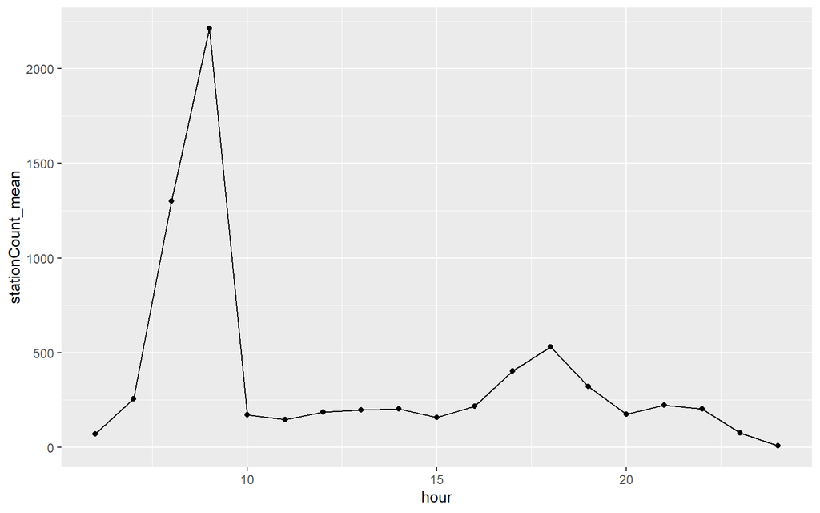

```r
Stats <- aggregate(cbind(tapIn,tapOut,stationCount_mean) ~ hour+stationName,data=station,FUN=mean)
Ser <- subset(Stats,Stats$stationName == "Little India NE7/DT12")
ggplot(data=Ser,mapping=aes(x=hour,y=stationCount_mean))+geom_point()+geom_line()
```

# Understanding the accuracy of our simulation.

After creating the simulation, we ran the simulation 20times to obtain 20 independent runs. We then use these values to run our post simulation analysis.

But first, we run some tests on the simulation output to make sure that our simulation is providing similar results to the existing data.

### Plotting the average station’s Tap In and Tap Out data.

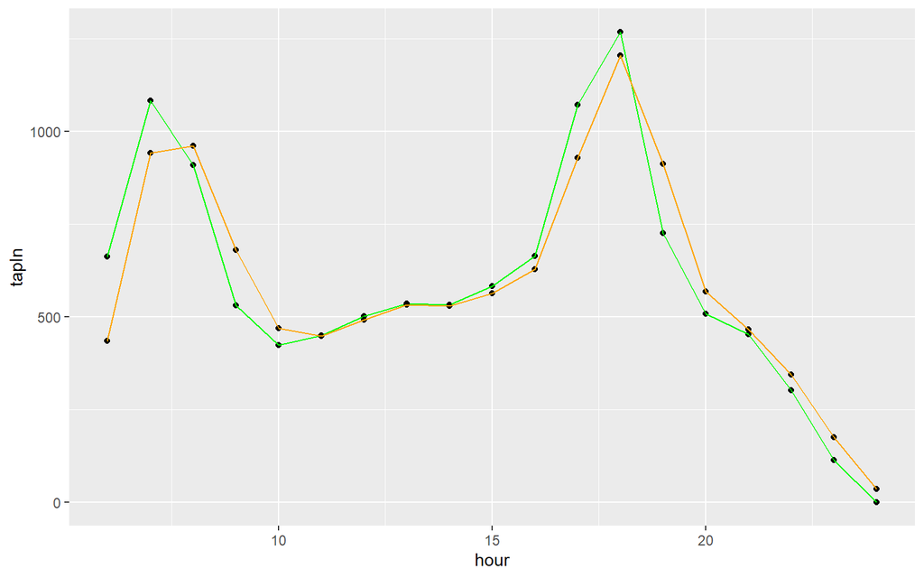

```r
Stats <- aggregate(cbind(tapIn,tapOut) ~ hour,data=station,FUN=mean)


ggplot() +
  # blue plot
geom_point(data=Stats, aes(x=hour, y=tapIn)) +
geom_line(data=Stats, aes(x=hour, y=tapIn), fill="green",
              colour="green") +
  # red plot
geom_point(data=Stats, aes(x=hour, y=tapOut)) +
geom_line(data=Stats, aes(x=hour, y=tapOut), fill="orange",
              colour="orange")
```

The graph plotted matches that of our pre-simulation analysis Weekday data which is a good indicator that our simulation is an accurate representation of Singapore’s MRT system.

Now let’s perform some PCA along with kmeans clustering and check if the hour clusters match that of our pre-simulation analysis.

## PCA-Kmeans analysis

```
## Too few points to calculate an ellipse
## Too few points to calculate an ellipse
```

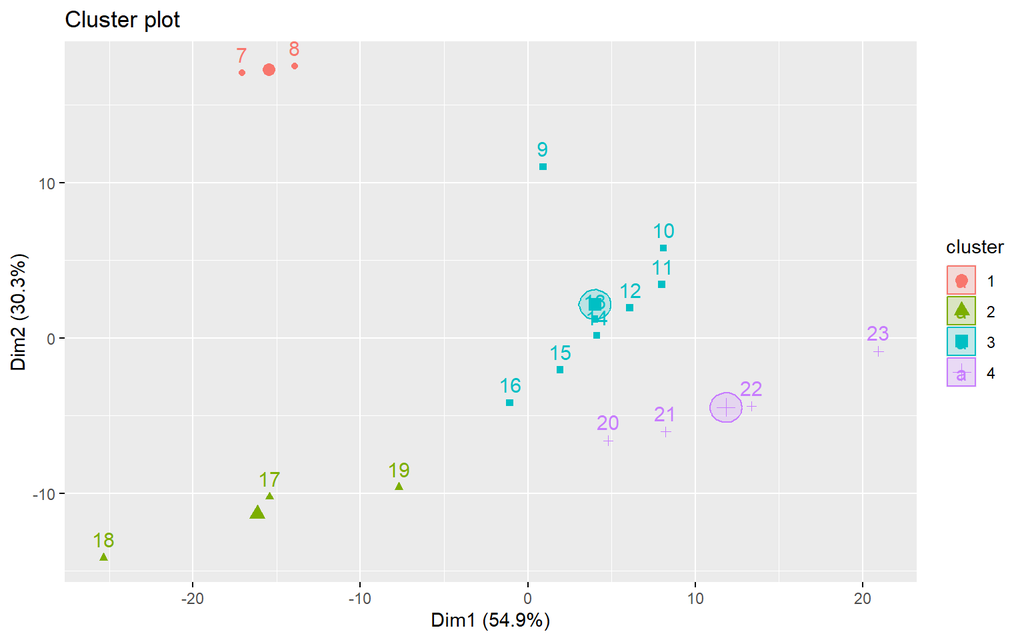

```r
Stats <- aggregate(cbind(tapIn,tapOut) ~ hour+stationName,data=station,FUN=mean)
Stats <- subset(Stats,hour!=6)
Stats <- subset(Stats,hour!=24)

wider <- pivot_wider(Stats, names_from= stationName, values_from = c(tapIn, tapOut))
wider <- mutate_all(wider, ~replace_na(.,0))
pca_data <- data.frame(wider[,-1])
rownames(pca_data) <- wider$hour
pca_data <- mutate_all(pca_data, ~replace_na(.,0))
k2 <- kmeans(scale(pca_data), centers=4, nstart=25)
fviz_cluster(k2, data = pca_data, ellipse.type = "euclid")
```

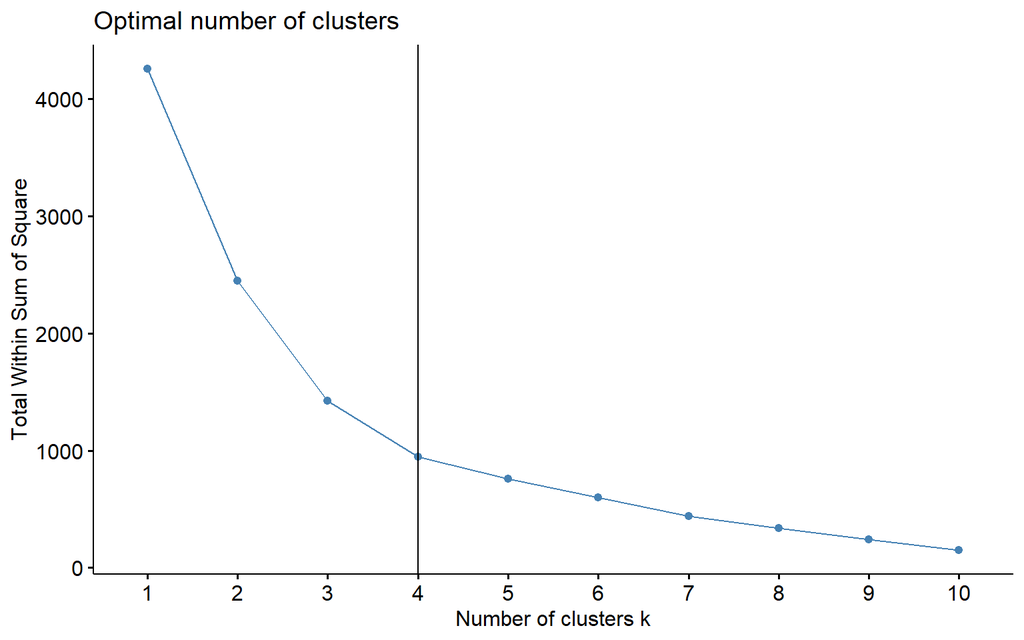

```r
fviz_nbclust(scale(pca_data), kmeans, nstart=100, method = "wss") +
  geom_vline(xintercept = 4, linetype = 1)
```

As we can see here, the Kmeans clustering has similar groups to that of our pre simulation analysis on the raw data. This can show that our simulation is an accurate representation of the actual MRT system. However, we still need to do more tests to confirm the accuracy of our simulation.

## Matching Tap In/Tap Out data with our pre-simulation analysis

[figure not shown]

```r
Stats <- aggregate(cbind(tapIn,tapOut) ~ hour + stationName,data=station,FUN=mean)
#unique(station$stationName)
# RP <- subset(Stats,stationName=="City Hall NS25/EW13")
# RP <- subset(Stats,stationName=="Raffles Place NS26/EW14")
RP <- subset(Stats,stationName=="Serangoon NE12/CC13")
#Stats <- subset(Stats,stationName=="Springleaf MRT Station TE4")
ggplot() +
  # blue plot
geom_point(data=RP, aes(x=hour, y=tapIn)) +
geom_line(data=RP, aes(x=hour, y=tapIn), fill="green",
              colour="green") +
  # red plot
geom_point(data=RP, aes(x=hour, y=tapOut)) +
geom_line(data=RP, aes(x=hour, y=tapOut), fill="orange",
              colour="orange") +

ggtitle("TapIn & TapOut by hour for Raffles Place NS26/EW14")
```

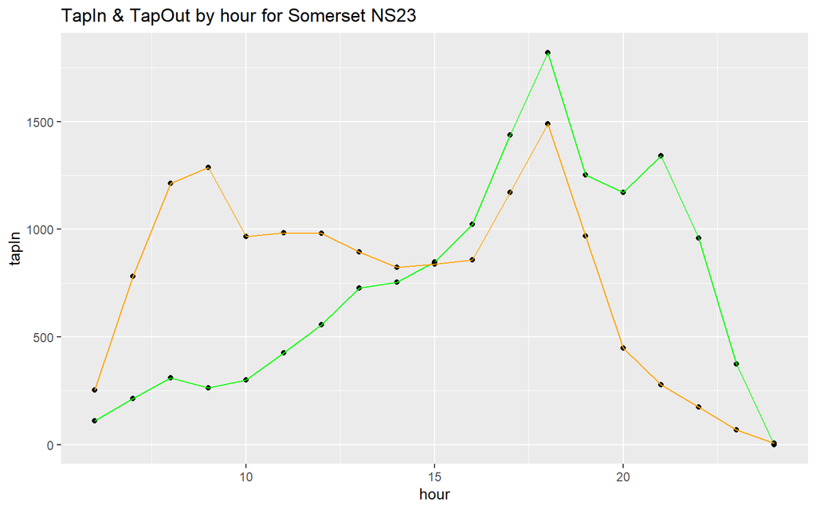

```r
Som <- subset(Stats,stationName=="Somerset NS23")
ggplot() +
  # blue plot
geom_point(data=Som, aes(x=hour, y=tapIn)) +
geom_line(data=Som, aes(x=hour, y=tapIn), fill="green",
              colour="green") +
  # red plot
geom_point(data=Som, aes(x=hour, y=tapOut)) +
geom_line(data=Som, aes(x=hour, y=tapOut), fill="orange",
              colour="orange") +

ggtitle("TapIn & TapOut by hour for Somerset NS23")
```

# Finding out the problem area in our system

## Performing PCA to find the pain points

It would make sense that high Tap in and Tap out data will make sense with congestion. Even though we cannot prove that with the raw data, we are able to use our simulation to find out the wait times associated with the stations that are highly commuted to.

We first perform PCA analysis on the data by station before clustering them using kmeans clustering to try figure out if the clusters formed can provide any insight into the congested stations.

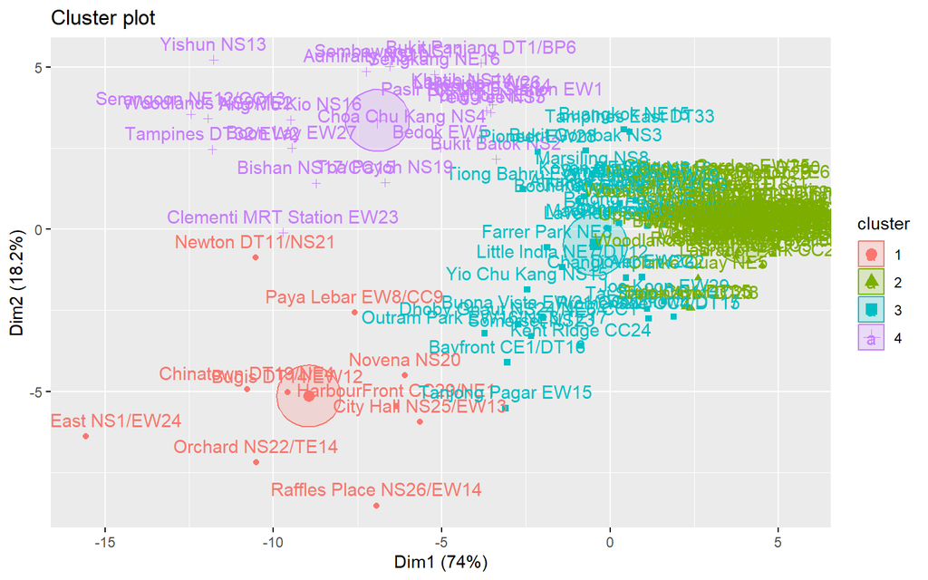

```r
Stats <- aggregate(cbind(tapIn,tapOut) ~ hour+stationName,data=station,FUN=mean)
Stats <- subset(Stats,hour!=6)
Stats <- subset(Stats,hour!=24)

wider <- pivot_wider(Stats, names_from = hour, values_from = c(tapIn, tapOut))
#wider <- mutate_all(wider, ~replace_na(.,0))
pca_data <- data.frame(wider[,-1])
rownames(pca_data) <- wider$stationName
pca_data <- mutate_all(pca_data, ~replace_na(.,0))
k2 <- kmeans(scale(pca_data), centers=4, nstart=25)
fviz_cluster(k2, data = pca_data, ellipse.type = "euclid")
```

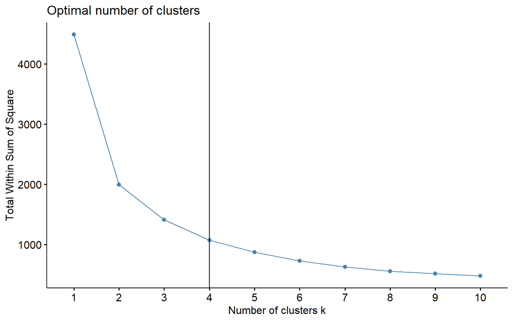

```r
fviz_nbclust(scale(pca_data), kmeans, nstart=100, method = "wss") +
  geom_vline(xintercept = 4, linetype = 1)
```

From the plot generated, we can quickly catch on to the fact that cluster 1 contains stations that are highly commuted to. Some stations include Jurong East, Raffles Place and Chinatown. Cluster 4 also contains stations that are frequently commuted to, incorporating stations like Bishan, Serangoon and Tampines.

Clusters 2 & 3 are more positive in terms of Dim1 as compared to Clusters 1 & 4. Instinctively, we assume that these stations in clusters 2 & 3 generally have less congested stations.

## Understanding our clusters

Using the clusters that we have established in the previous portion, we can now perform a more in depth analysis into these station to find out why they have been clustered together.

```r
rownames(as.data.frame(subset(k2$cluster,k2$cluster == 1 | k2$cluster == 4)))
```

```
##  [1] "Admiralty NS10"            "Ang Mo Kio NS16"
##  [3] "Bedok EW5"                 "Bishan NS17/CC15"
##  [5] "Boon Lay EW27"             "Bugis DT14/EW12"
##  [7] "Bukit Batok NS2"           "Bukit Panjang DT1/BP6"
##  [9] "Chinatown DT19/NE4"        "Choa Chu Kang NS4"
## [11] "City Hall NS25/EW13"       "Clementi MRT Station EW23"
## [13] "HarbourFront CC29/NE1"     "Hougang NE14"
## [15] "Jurong East NS1/EW24"      "Khatib NS14"
## [17] "Lakeside EW26"             "Newton DT11/NS21"
## [19] "Novena NS20"               "Orchard NS22/TE14"
## [21] "Pasir Ris MRT Station EW1" "Paya Lebar EW8/CC9"
## [23] "Punggol NE17"              "Raffles Place NS26/EW14"
## [25] "Sembawang NS11"            "Sengkang NE16"
## [27] "Serangoon NE12/CC13"       "Tampines DT32/EW2"
## [29] "Toa Payoh NS19"            "Woodlands NS9/TE2"
## [31] "Yew Tee NS5"               "Yishun NS13"
```

```r
df <- as.data.frame(subset(k2$cluster,k2$cluster == 1 | k2$cluster == 4))
df1 <- as.data.frame(subset(k2$cluster,k2$cluster == 1))
df2 <- as.data.frame(subset(k2$cluster,k2$cluster == 2))
df3 <- as.data.frame(subset(k2$cluster,k2$cluster == 3))
df4 <- as.data.frame(subset(k2$cluster,k2$cluster == 4))
colnames(df) <- "Cluster"
colnames(df1) <- "Cluster"
colnames(df2) <- "Cluster"
colnames(df3) <- "Cluster"
colnames(df4) <- "Cluster"
# df
# df1
# df4
#View(df)
```

Function `ClusterData` takes in each cluster as a dataframe and returns a dataframe containing the Tap in and Tap out data of the stations in the cluster subsetted from the Stats dataframe.

```r
ClusterData <- function(df) {
  Stats <- aggregate(cbind(tapIn,tapOut) ~ hour+stationName,data=station,FUN=mean)
  Temp2 <- data.frame()
  for (i in 1:length(rownames(df))) {
    Temp1 <- subset(Stats,stationName==rownames(df)[i])
    Temp2 <- rbind(Temp2,Temp1)
  }
  return(Temp2)
}
```

## Plotting the clusters

We can now plot the graphs of each station split by cluster.

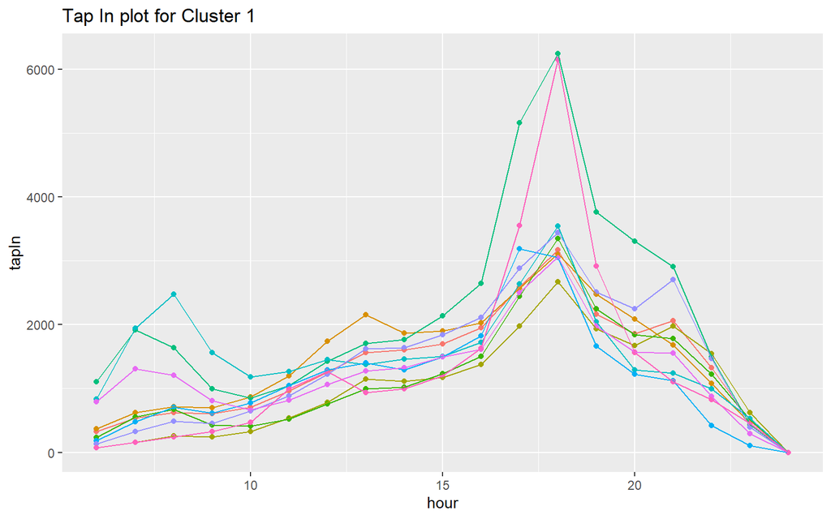

```r
Stats <- aggregate(cbind(tapIn,tapOut) ~ hour + stationName,data=station,FUN=mean)
Cluster1 <- ClusterData(df1)
Cluster2 <- ClusterData(df2)
Cluster3 <- ClusterData(df3)
Cluster4 <- ClusterData(df4)
ggplot(data=Cluster1,mapping=aes(x=hour,y=tapIn,color=stationName))+geom_point()+geom_line()+
  ggtitle("Tap In plot for Cluster 1") + guides(color = FALSE)
```

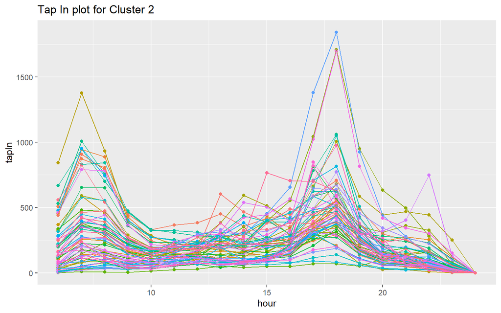

```r
ggplot(data=Cluster2,mapping=aes(x=hour,y=tapIn,color=stationName))+geom_point()+geom_line()+
  ggtitle("Tap In plot for Cluster 2") + guides(color = FALSE)
```

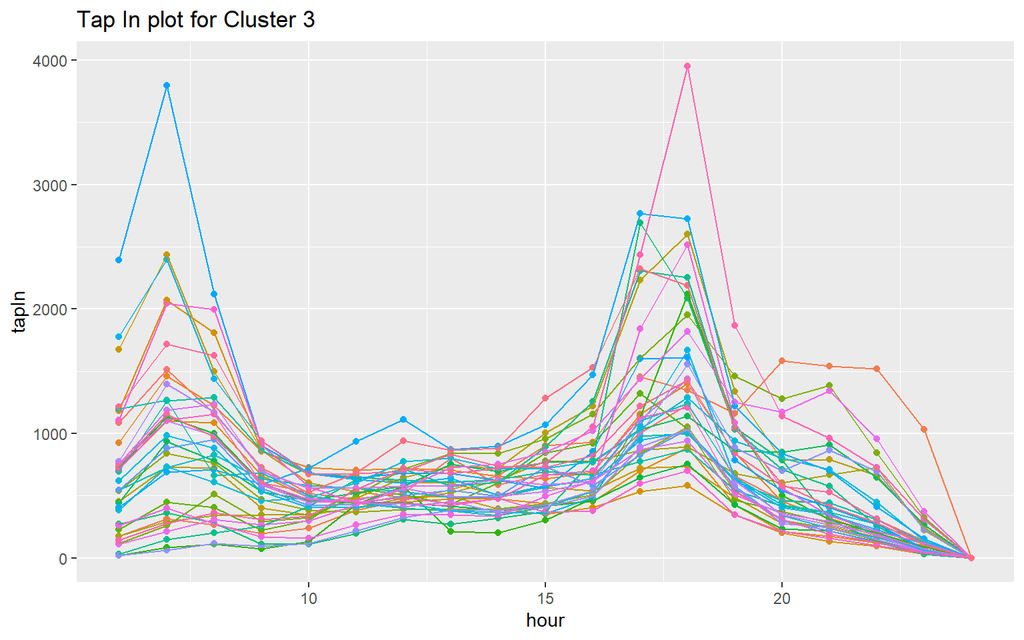

```r
ggplot(data=Cluster3,mapping=aes(x=hour,y=tapIn,color=stationName))+geom_point()+geom_line()+
  ggtitle("Tap In plot for Cluster 3") + guides(color = FALSE)
```

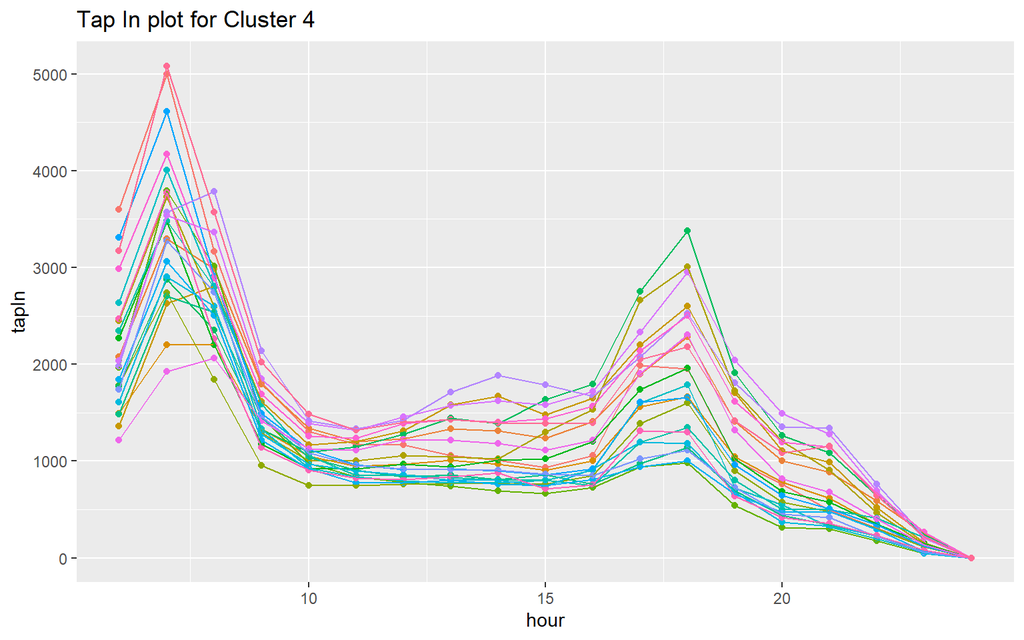

```r
ggplot(data=Cluster4,mapping=aes(x=hour,y=tapIn,color=stationName))+geom_point()+geom_line()+
  ggtitle("Tap In plot for Cluster 4") + guides(color = FALSE)
```

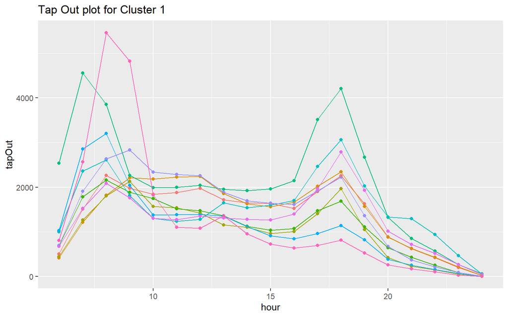

```r
ggplot(data=Cluster1,mapping=aes(x=hour,y=tapOut,color=stationName))+geom_point()+geom_line()+
  ggtitle("Tap Out plot for Cluster 1") + guides(color = FALSE)
```

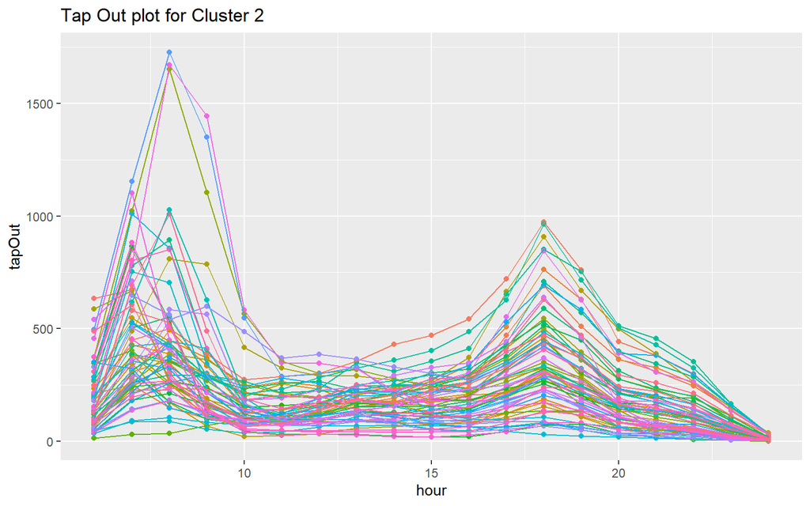

```r
ggplot(data=Cluster2,mapping=aes(x=hour,y=tapOut,color=stationName))+geom_point()+geom_line()+
  ggtitle("Tap Out plot for Cluster 2") + guides(color = FALSE)
```

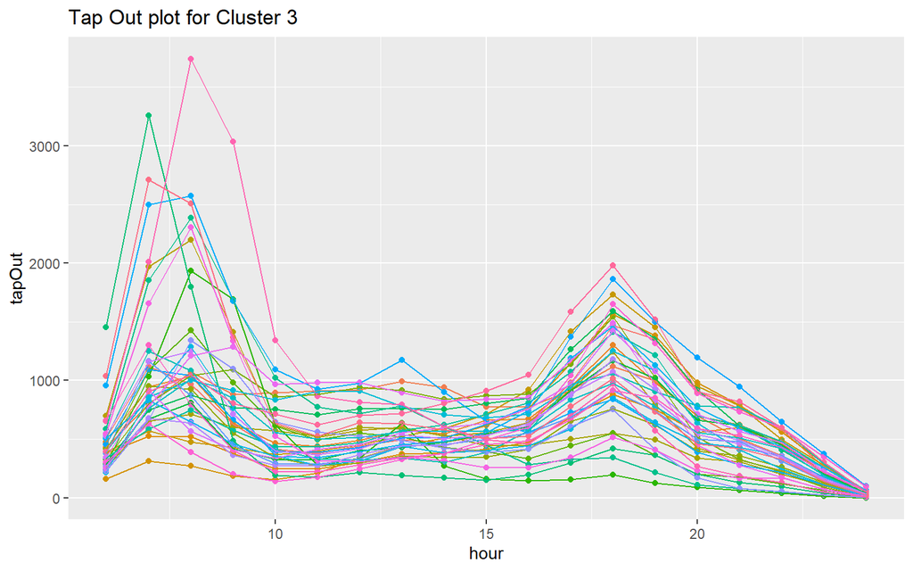

```r
ggplot(data=Cluster3,mapping=aes(x=hour,y=tapOut,color=stationName))+geom_point()+geom_line()+
  ggtitle("Tap Out plot for Cluster 3") + guides(color = FALSE)
```

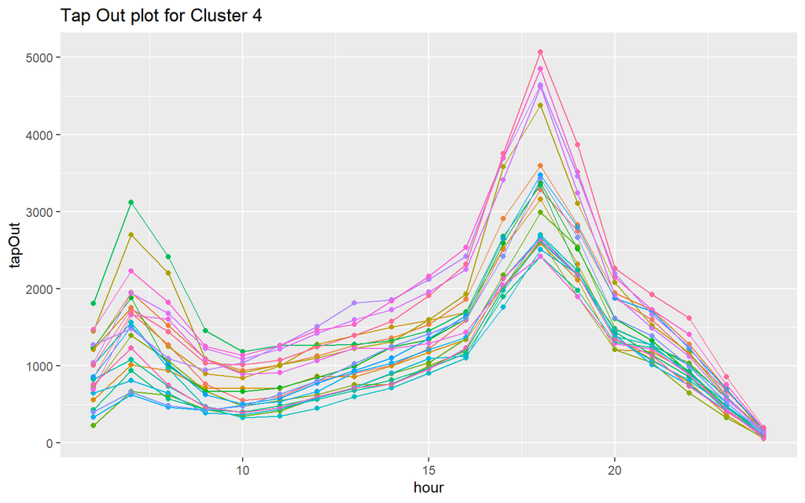

```r
ggplot(data=Cluster4,mapping=aes(x=hour,y=tapOut,color=stationName))+geom_point()+geom_line()+
  ggtitle("Tap Out plot for Cluster 4") + guides(color = FALSE)
```

Cluster 3 has slightly more commuters tapping in and out with off peak values slightly below 1000.

# Finding out the congestion using waiting time

## Wait time analysis

Now that we have established that our simulation is an accurate representation of Singapore’s MRT system and have identified the problem stations that we should be looking at, we can now look at the train data to further understand how we can improve the current simluation and hence provide a solution to the possible problems that our MRT system faces.

Again we will use PCA to attempt to find out the waiting time and train capacity in relation to hour and direction.

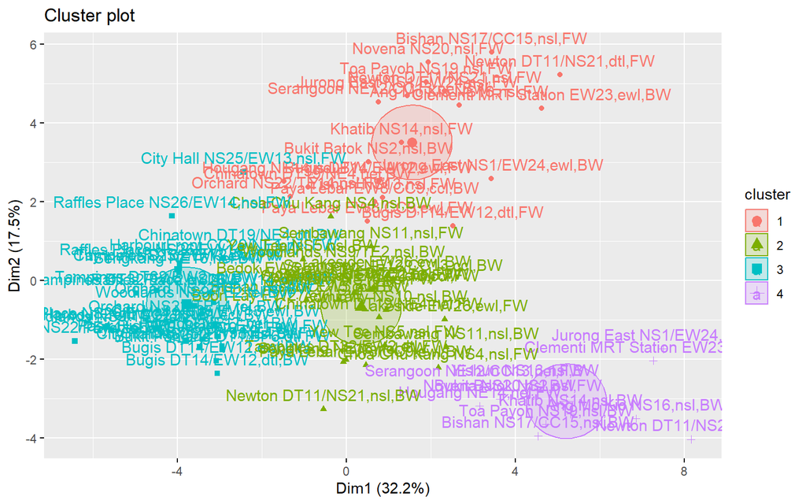

```r
trainStats <- data.frame()
for (i in 1:nrow(df)) {
  stations <- subset(train,train$stationName==rownames(df)[i])
  trainStats <- rbind(trainStats,stations)
}
trainStats <- aggregate(cbind(alightCount_mean, alightCount_count, boardCount_mean, boardCount_count, waitTime_mean,trainCount_mean) ~ hour+stationName+direction+line,data=trainStats,FUN=mean)
trainStats <- subset(trainStats,hour!=6)
trainStats <- subset(trainStats,hour!=24)
trainStats$stationName <- paste(trainStats$stationName,trainStats$line,trainStats$direction, sep=",")
trainStats <- trainStats[c(1,2,9,10)]

wider <- pivot_wider(trainStats, names_from = hour, values_from = c(waitTime_mean,trainCount_mean))
#wider <- mutate_all(wider, ~replace_na(.,0))
pca_data <- data.frame(wider[,-1])
rownames(pca_data) <- wider$stationName
pca_data <- mutate_all(pca_data, ~replace_na(.,0))
k2 <- kmeans(scale(pca_data), centers=4, nstart=25)
fviz_cluster(k2, data = pca_data, ellipse.type = "euclid")
```

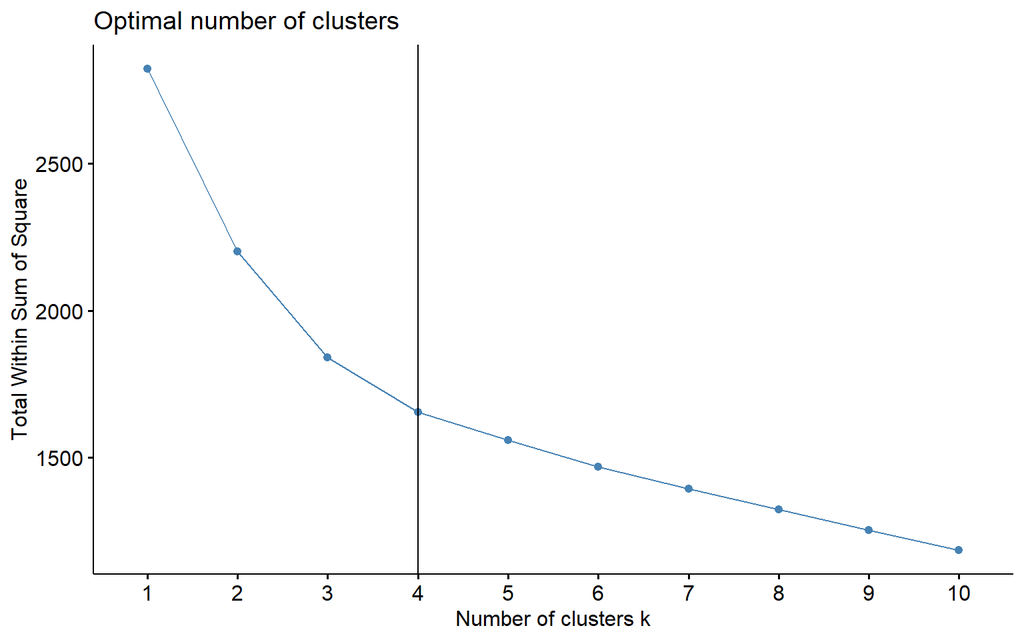

```r
fviz_nbclust(scale(pca_data), kmeans, nstart=100, method = "wss") +
  geom_vline(xintercept = 4, linetype = 1)
```

```r
# rownames(as.data.frame(subset(k2$cluster,k2$cluster == 1 | k2$cluster == 4)))
df1 <- as.data.frame(subset(k2$cluster,k2$cluster == 1))
df2 <- as.data.frame(subset(k2$cluster,k2$cluster == 2))
df3 <- as.data.frame(subset(k2$cluster,k2$cluster == 3))
df4 <- as.data.frame(subset(k2$cluster,k2$cluster == 4))
colnames(df1) <- "Cluster"
colnames(df2) <- "Cluster"
colnames(df3) <- "Cluster"
colnames(df4) <- "Cluster"
```

Function `ClusterTrainData` takes in the cluster dataframe as an input and provides the traindata on those stations.

```r
ClusterTrainData <- function(df) {
  trainStats <- aggregate(cbind(alightCount_mean, alightCount_count, boardCount_mean, boardCount_count, waitTime_mean,trainCount_mean,trainCount_sd,trainCount_count) ~ hour+stationName+direction+line,data=train,FUN=mean)
  Temp2 <- data.frame()
  for (i in 1:length(rownames(df))) {
    rowname <- as.data.frame(strsplit(rownames(df)[i],","))[1,]
    Sline <- as.data.frame(strsplit(rownames(df)[i],","))[2,]
    Sdirection <- as.data.frame(strsplit(rownames(df)[i],","))[3,]
    Temp1 <- subset(trainStats,stationName==rowname & line==Sline & direction==Sdirection)
    Temp2 <- rbind(Temp2,Temp1)
  }
  return(Temp2)
}
```

We can now generate data frames to include the alightCount_mean, alightCount_count, boardCount_mean, boardCount_count, waitTime_mean & trainCount_mean.

```r
Cluster1TrainData <- ClusterTrainData(df1)
Cluster2TrainData <- ClusterTrainData(df2)
Cluster3TrainData <- ClusterTrainData(df3)
Cluster4TrainData <- ClusterTrainData(df4)
```

We plot the data of TrainCount_mean against hour by each station,line and direction.

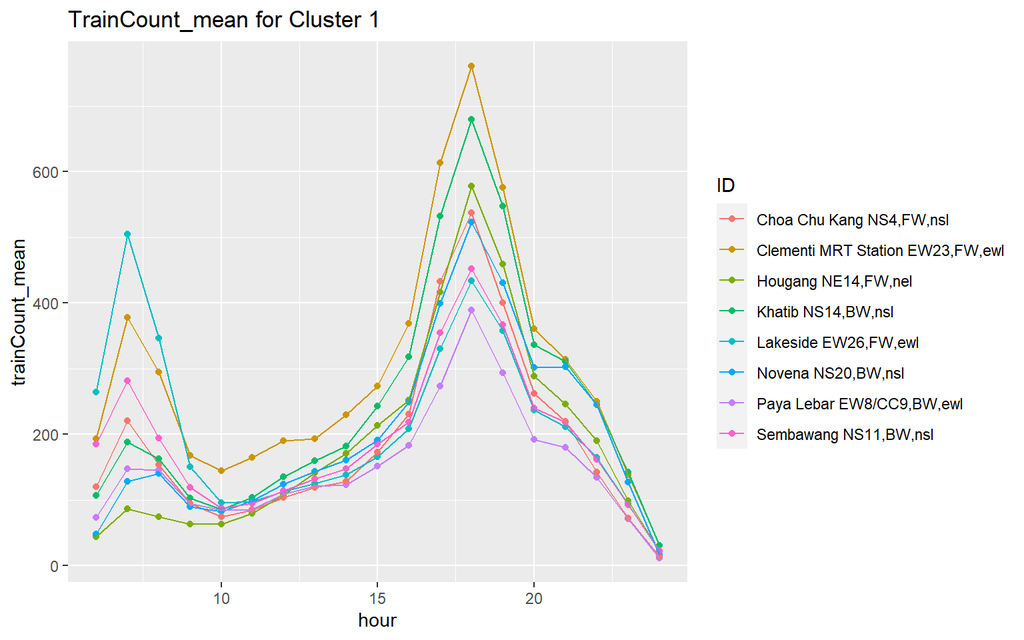

```r
Cluster1TrainData$ID <- paste(Cluster1TrainData$stationName,Cluster1TrainData$direction,Cluster1TrainData$line,sep=",")
Cluster2TrainData$ID <- paste(Cluster2TrainData$stationName,Cluster2TrainData$direction,Cluster2TrainData$line,sep=",")
Cluster3TrainData$ID <- paste(Cluster3TrainData$stationName,Cluster3TrainData$direction,Cluster3TrainData$line,sep=",")
Cluster4TrainData$ID <- paste(Cluster4TrainData$stationName,Cluster4TrainData$direction,Cluster4TrainData$line,sep=",")
ggplot(data=Cluster1TrainData,mapping=aes(x=hour,y=trainCount_mean,color=ID))+geom_point()+geom_line() +
    ggtitle("TrainCount_mean for Cluster 1")
```

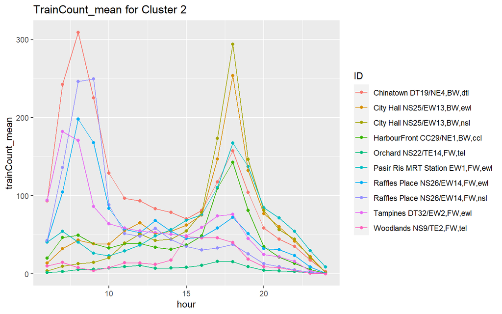

```r
ggplot(data=Cluster2TrainData,mapping=aes(x=hour,y=trainCount_mean,color=ID))+geom_point()+geom_line() +
    ggtitle("TrainCount_mean for Cluster 2")
```

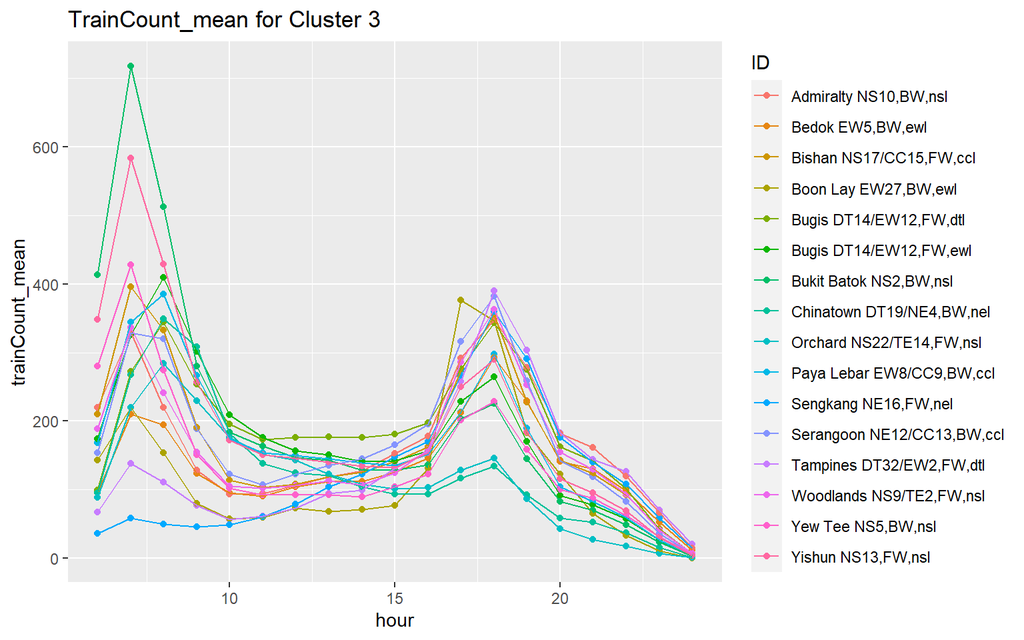

```r
ggplot(data=Cluster3TrainData,mapping=aes(x=hour,y=trainCount_mean,color=ID))+geom_point()+geom_line() +
    ggtitle("TrainCount_mean for Cluster 3")
```

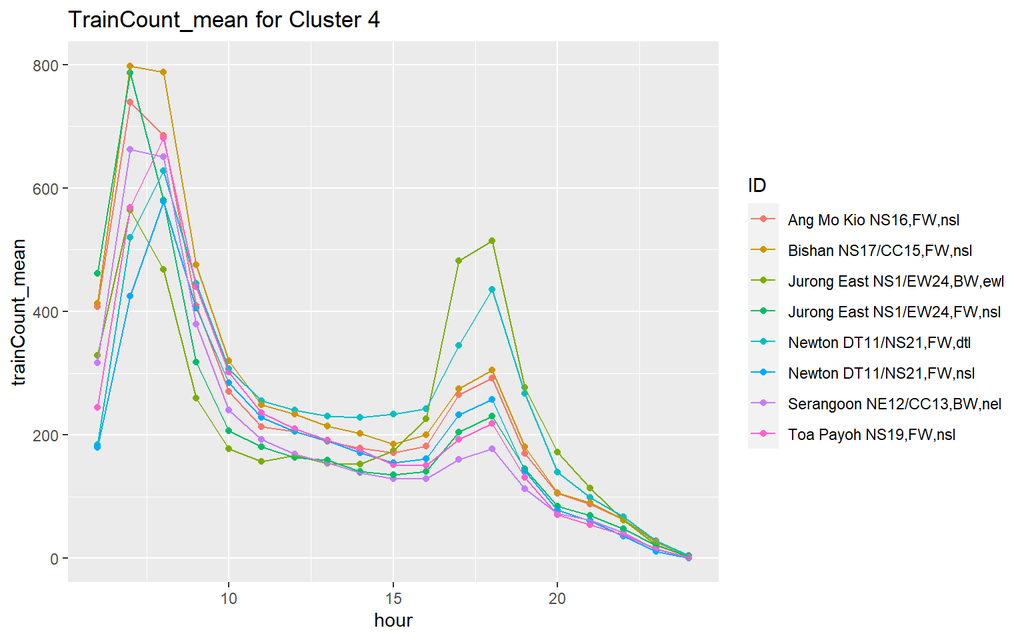

```r
ggplot(data=Cluster4TrainData,mapping=aes(x=hour,y=trainCount_mean,color=ID))+geom_point()+geom_line() +
    ggtitle("TrainCount_mean for Cluster 4")
```

We can see that Cluster 1-4 differ in terms of the hour and magnitude of the spike in trainCount_mean as well as the average trainCount_mean value.

```r
subset(Cluster1TrainData,Cluster1TrainData$hour <= 8 & Cluster1TrainData$trainCount_mean>=600)
```

```
##  [1] hour              stationName       direction         line
##  [5] alightCount_mean  alightCount_count boardCount_mean   boardCount_count
##  [9] waitTime_mean     trainCount_mean   ID
## <0 rows> (or 0-length row.names)
```

```r
subset(Cluster4TrainData, 17 <= Cluster4TrainData$hour & Cluster4TrainData$hour <= 19 & Cluster4TrainData$trainCount_mean>=600)
```

```
##  [1] hour              stationName       direction         line
##  [5] alightCount_mean  alightCount_count boardCount_mean   boardCount_count
##  [9] waitTime_mean     trainCount_mean   ID
## <0 rows> (or 0-length row.names)
```